# Results - area per area for areas with only oceanic habitat

Lola Gilbert

31/03/2022

# California current

Survey area only covered oceanic habitats here, so we just look at the contribution of taxa.

## Excretion per taxa

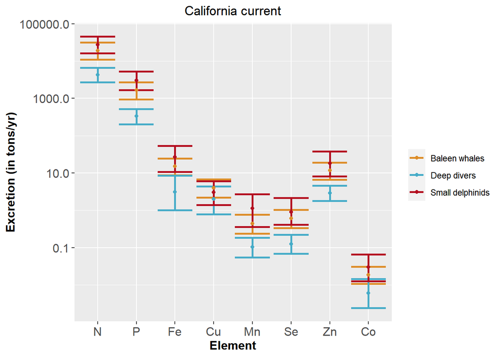

Are the differences significant ?

| Geo_area | Element | Group1 | Group2 | ratio_group1_superior_to_group2 |
| --- | --- | --- | --- | --- |
| California current | N | Baleen whales | Deep divers | 1.000 |
| California current | N | Baleen whales | Small delphinids | 0.147 |
| California current | N | Deep divers | Small delphinids | 0.000 |
| California current | P | Baleen whales | Deep divers | 0.999 |
| California current | P | Baleen whales | Small delphinids | 0.061 |
| California current | P | Deep divers | Small delphinids | 0.000 |
| California current | Fe | Baleen whales | Deep divers | 0.998 |
| California current | Fe | Baleen whales | Small delphinids | 0.106 |
| California current | Fe | Deep divers | Small delphinids | 0.000 |
| California current | Cu | Baleen whales | Deep divers | 0.911 |
| California current | Cu | Baleen whales | Small delphinids | 0.740 |
| California current | Cu | Deep divers | Small delphinids | 0.127 |
| California current | Mn | Baleen whales | Deep divers | 1.000 |
| California current | Mn | Baleen whales | Small delphinids | 0.050 |
| California current | Mn | Deep divers | Small delphinids | 0.000 |
| California current | Se | Baleen whales | Deep divers | 1.000 |
| California current | Se | Baleen whales | Small delphinids | 0.251 |
| California current | Se | Deep divers | Small delphinids | 0.000 |
| California current | Zn | Baleen whales | Deep divers | 1.000 |
| California current | Zn | Baleen whales | Small delphinids | 0.162 |
| California current | Zn | Deep divers | Small delphinids | 0.000 |
| California current | Co | Baleen whales | Deep divers | 0.980 |
| California current | Co | Baleen whales | Small delphinids | 0.179 |
| California current | Co | Deep divers | Small delphinids | 0.000 |

What are there relative contribution to total excretion in this area ?

| Geo_area | Eco_gp | Element | mean | mean_total | ratio_contribution |
| --- | --- | --- | --- | --- | --- |
| California current | Baleen whales | N | 19055.2615303 | 50967.2369876 | 0.3738728 |
| California current | Baleen whales | P | 1653.1371370 | 5000.5033813 | 0.3305941 |
| California current | Baleen whales | Fe | 14.9388089 | 45.0828410 | 0.3313635 |
| California current | Baleen whales | Cu | 4.0041494 | 9.0407575 | 0.4428998 |
| California current | Baleen whales | Mn | 0.4437373 | 1.6650361 | 0.2665031 |
| California current | Baleen whales | Se | 0.6140032 | 1.6414707 | 0.3740567 |
| California current | Baleen whales | Zn | 11.6522635 | 32.7874614 | 0.3553878 |
| California current | Baleen whales | Co | 0.0184153 | 0.0546721 | 0.3368326 |
| California current | Baleen whales | As | 4.8266322 | 10.0994506 | 0.4779104 |
| California current | Deep divers | N | 4261.6866129 | 50967.2369876 | 0.0836162 |
| California current | Deep divers | P | 335.6030524 | 5000.5033813 | 0.0671139 |
| California current | Deep divers | Fe | 3.1009938 | 45.0828410 | 0.0687843 |
| California current | Deep divers | Cu | 1.9827434 | 9.0407575 | 0.2193116 |
| California current | Deep divers | Mn | 0.1032095 | 1.6650361 | 0.0619864 |
| California current | Deep divers | Se | 0.1259717 | 1.6414707 | 0.0767432 |
| California current | Deep divers | Zn | 2.9140556 | 32.7874614 | 0.0888771 |
| California current | Deep divers | Co | 0.0060423 | 0.0546721 | 0.1105190 |
| California current | Deep divers | As | 1.1135210 | 10.0994506 | 0.1102556 |
| California current | Small delphinids | N | 27650.2888444 | 50967.2369876 | 0.5425110 |
| California current | Small delphinids | P | 3011.7631919 | 5000.5033813 | 0.6022920 |
| California current | Small delphinids | Fe | 27.0430383 | 45.0828410 | 0.5998521 |
| California current | Small delphinids | Cu | 3.0538647 | 9.0407575 | 0.3377886 |
| California current | Small delphinids | Mn | 1.1180893 | 1.6650361 | 0.6715105 |
| California current | Small delphinids | Se | 0.9014958 | 1.6414707 | 0.5492001 |
| California current | Small delphinids | Zn | 18.2211423 | 32.7874614 | 0.5557351 |
| California current | Small delphinids | Co | 0.0302144 | 0.0546721 | 0.5526484 |
| California current | Small delphinids | As | 4.1592974 | 10.0994506 | 0.4118340 |

# Gulf of Mexico

Survey area only included oceanic habitat here, so we just look at the contributions of taxa.

## Excretion per taxa

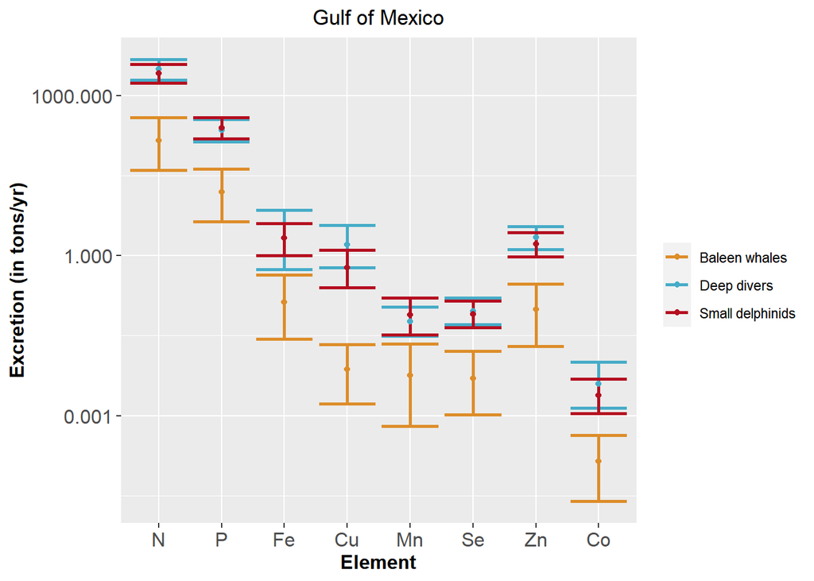

Are the differences significant ?

| Geo_area | Element | Group1 | Group2 | ratio_group1_superior_to_group2 |
| --- | --- | --- | --- | --- |
| Gulf of Mexico | N | Baleen whales | Deep divers | 0.000 |
| Gulf of Mexico | N | Baleen whales | Small delphinids | 0.000 |
| Gulf of Mexico | N | Deep divers | Small delphinids | 0.694 |
| Gulf of Mexico | P | Baleen whales | Deep divers | 0.000 |
| Gulf of Mexico | P | Baleen whales | Small delphinids | 0.000 |
| Gulf of Mexico | P | Deep divers | Small delphinids | 0.369 |
| Gulf of Mexico | Fe | Baleen whales | Deep divers | 0.001 |
| Gulf of Mexico | Fe | Baleen whales | Small delphinids | 0.000 |
| Gulf of Mexico | Fe | Deep divers | Small delphinids | 0.355 |
| Gulf of Mexico | Cu | Baleen whales | Deep divers | 0.000 |
| Gulf of Mexico | Cu | Baleen whales | Small delphinids | 0.000 |
| Gulf of Mexico | Cu | Deep divers | Small delphinids | 0.997 |
| Gulf of Mexico | Mn | Baleen whales | Deep divers | 0.000 |
| Gulf of Mexico | Mn | Baleen whales | Small delphinids | 0.000 |
| Gulf of Mexico | Mn | Deep divers | Small delphinids | 0.290 |
| Gulf of Mexico | Se | Baleen whales | Deep divers | 0.000 |
| Gulf of Mexico | Se | Baleen whales | Small delphinids | 0.000 |
| Gulf of Mexico | Se | Deep divers | Small delphinids | 0.662 |
| Gulf of Mexico | Zn | Baleen whales | Deep divers | 0.000 |
| Gulf of Mexico | Zn | Baleen whales | Small delphinids | 0.000 |
| Gulf of Mexico | Zn | Deep divers | Small delphinids | 0.783 |
| Gulf of Mexico | Co | Baleen whales | Deep divers | 0.000 |
| Gulf of Mexico | Co | Baleen whales | Small delphinids | 0.000 |
| Gulf of Mexico | Co | Deep divers | Small delphinids | 0.815 |

What are their relative contribution to total excretion in this area ?

| Geo_area | Eco_gp | Element | mean | mean_total | ratio_contribution |
| --- | --- | --- | --- | --- | --- |
| Gulf of Mexico | Baleen whales | N | 144.8935821 | 5893.4661508 | 0.0245855 |
| Gulf of Mexico | Baleen whales | P | 15.7617617 | 485.1228888 | 0.0324902 |
| Gulf of Mexico | Baleen whales | Fe | 0.1346957 | 4.4382463 | 0.0303489 |
| Gulf of Mexico | Baleen whales | Cu | 0.0074300 | 2.2091086 | 0.0033634 |
| Gulf of Mexico | Baleen whales | Mn | 0.0056892 | 0.1424153 | 0.0399480 |
| Gulf of Mexico | Baleen whales | Se | 0.0050017 | 0.1764058 | 0.0283534 |
| Gulf of Mexico | Baleen whales | Zn | 0.0978789 | 3.9044036 | 0.0250689 |
| Gulf of Mexico | Baleen whales | Co | 0.0001393 | 0.0065326 | 0.0213163 |
| Gulf of Mexico | Baleen whales | As | 0.0157528 | 1.2417729 | 0.0126857 |
| Gulf of Mexico | Deep divers | N | 3104.5420794 | 5893.4661508 | 0.5267769 |
| Gulf of Mexico | Deep divers | P | 222.3940098 | 485.1228888 | 0.4584282 |
| Gulf of Mexico | Deep divers | Fe | 2.1462625 | 4.4382463 | 0.4835835 |
| Gulf of Mexico | Deep divers | Cu | 1.6051374 | 2.2091086 | 0.7265996 |
| Gulf of Mexico | Deep divers | Mn | 0.0581354 | 0.1424153 | 0.4082104 |
| Gulf of Mexico | Deep divers | Se | 0.0916741 | 0.1764058 | 0.5196775 |
| Gulf of Mexico | Deep divers | Zn | 2.1698701 | 3.9044036 | 0.5557494 |
| Gulf of Mexico | Deep divers | Co | 0.0039920 | 0.0065326 | 0.6110871 |
| Gulf of Mexico | Deep divers | As | 0.7228350 | 1.2417729 | 0.5820991 |
| Gulf of Mexico | Small delphinids | N | 2644.0304893 | 5893.4661508 | 0.4486376 |
| Gulf of Mexico | Small delphinids | P | 246.9671173 | 485.1228888 | 0.5090816 |
| Gulf of Mexico | Small delphinids | Fe | 2.1572881 | 4.4382463 | 0.4860677 |
| Gulf of Mexico | Small delphinids | Cu | 0.5965412 | 2.2091086 | 0.2700371 |
| Gulf of Mexico | Small delphinids | Mn | 0.0785907 | 0.1424153 | 0.5518417 |
| Gulf of Mexico | Small delphinids | Se | 0.0797299 | 0.1764058 | 0.4519690 |
| Gulf of Mexico | Small delphinids | Zn | 1.6366546 | 3.9044036 | 0.4191817 |
| Gulf of Mexico | Small delphinids | Co | 0.0024014 | 0.0065326 | 0.3675966 |
| Gulf of Mexico | Small delphinids | As | 0.5031852 | 1.2417729 | 0.4052151 |

# New Caledonia

Survey area only included oceanic habitat here, so we just look at the contributions of taxa.

## Excretion per taxa

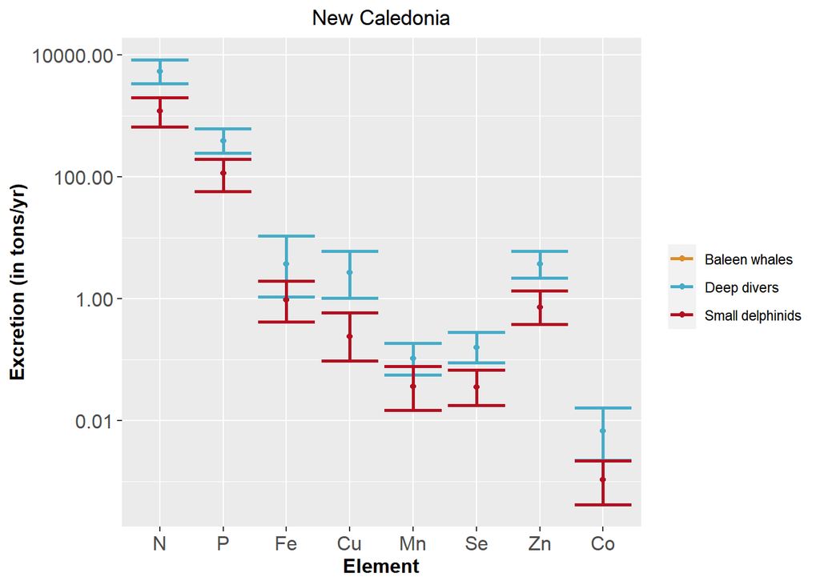

Are the differences significant ?

| Geo_area | Element | Group1 | Group2 | ratio_group1_superior_to_group2 |
| --- | --- | --- | --- | --- |
| New Caledonia | N | Deep divers | Small delphinids | 1.000 |
| New Caledonia | P | Deep divers | Small delphinids | 0.999 |
| New Caledonia | Fe | Deep divers | Small delphinids | 0.977 |
| New Caledonia | Cu | Deep divers | Small delphinids | 1.000 |
| New Caledonia | Mn | Deep divers | Small delphinids | 0.983 |
| New Caledonia | Se | Deep divers | Small delphinids | 0.999 |
| New Caledonia | Zn | Deep divers | Small delphinids | 1.000 |
| New Caledonia | Co | Deep divers | Small delphinids | 1.000 |

What are their relative contribution to total excretion in this area ?

| Geo_area | Eco_gp | Element | mean | mean_total | ratio_contribution |
| --- | --- | --- | --- | --- | --- |
| New Caledonia | Deep divers | N | 5334.6334473 | 6536.6318408 | 0.8161135 |
| New Caledonia | Deep divers | P | 389.2449947 | 502.7103297 | 0.7742928 |
| New Caledonia | Deep divers | Fe | 3.6894541 | 4.6373220 | 0.7956001 |
| New Caledonia | Deep divers | Cu | 2.6842403 | 2.9219241 | 0.9186550 |
| New Caledonia | Deep divers | Mn | 0.1031017 | 0.1389711 | 0.7418926 |
| New Caledonia | Deep divers | Se | 0.1589346 | 0.1946768 | 0.8164025 |
| New Caledonia | Deep divers | Zn | 3.7208066 | 4.4460140 | 0.8368859 |
| New Caledonia | Deep divers | Co | 0.0067574 | 0.0078193 | 0.8642038 |
| New Caledonia | Deep divers | As | 1.2425279 | 1.4863452 | 0.8359619 |
| New Caledonia | Small delphinids | N | 1201.9983936 | 6536.6318408 | 0.1838865 |
| New Caledonia | Small delphinids | P | 113.4653350 | 502.7103297 | 0.2257072 |
| New Caledonia | Small delphinids | Fe | 0.9478679 | 4.6373220 | 0.2043999 |
| New Caledonia | Small delphinids | Cu | 0.2376838 | 2.9219241 | 0.0813450 |
| New Caledonia | Small delphinids | Mn | 0.0358695 | 0.1389711 | 0.2581074 |
| New Caledonia | Small delphinids | Se | 0.0357422 | 0.1946768 | 0.1835975 |
| New Caledonia | Small delphinids | Zn | 0.7252074 | 4.4460140 | 0.1631141 |
| New Caledonia | Small delphinids | Co | 0.0010618 | 0.0078193 | 0.1357962 |
| New Caledonia | Small delphinids | As | 0.2438173 | 1.4863452 | 0.1640381 |

# Hawaii

Survey area only included oceanic habitat here, so we just look at the contributions of taxa.

## Excretion per taxa

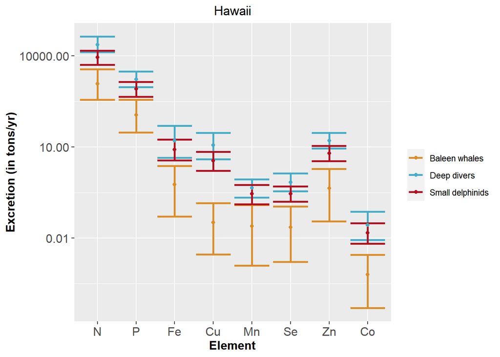

Are the differences significant ?

| Geo_area | Element | Group1 | Group2 | ratio_group1_superior_to_group2 |
| --- | --- | --- | --- | --- |
| Hawaii | N | Baleen whales | Deep divers | 0.000 |
| Hawaii | N | Baleen whales | Small delphinids | 0.002 |
| Hawaii | N | Deep divers | Small delphinids | 0.993 |
| Hawaii | P | Baleen whales | Deep divers | 0.000 |
| Hawaii | P | Baleen whales | Small delphinids | 0.004 |
| Hawaii | P | Deep divers | Small delphinids | 0.971 |
| Hawaii | Fe | Baleen whales | Deep divers | 0.000 |
| Hawaii | Fe | Baleen whales | Small delphinids | 0.001 |
| Hawaii | Fe | Deep divers | Small delphinids | 0.834 |
| Hawaii | Cu | Baleen whales | Deep divers | 0.000 |
| Hawaii | Cu | Baleen whales | Small delphinids | 0.000 |
| Hawaii | Cu | Deep divers | Small delphinids | 0.989 |
| Hawaii | Mn | Baleen whales | Deep divers | 0.001 |
| Hawaii | Mn | Baleen whales | Small delphinids | 0.003 |
| Hawaii | Mn | Deep divers | Small delphinids | 0.827 |
| Hawaii | Se | Baleen whales | Deep divers | 0.000 |
| Hawaii | Se | Baleen whales | Small delphinids | 0.003 |
| Hawaii | Se | Deep divers | Small delphinids | 0.975 |
| Hawaii | Zn | Baleen whales | Deep divers | 0.000 |
| Hawaii | Zn | Baleen whales | Small delphinids | 0.002 |
| Hawaii | Zn | Deep divers | Small delphinids | 0.990 |
| Hawaii | Co | Baleen whales | Deep divers | 0.000 |
| Hawaii | Co | Baleen whales | Small delphinids | 0.000 |
| Hawaii | Co | Deep divers | Small delphinids | 0.818 |

What are their relative contribution to total excretion in this area ?

| Geo_area | Eco_gp | Element | mean | mean_total | ratio_contribution |
| --- | --- | --- | --- | --- | --- |
| Hawaii | Baleen whales | N | 1226.5603075 | 33651.4724872 | 0.0364489 |
| Hawaii | Baleen whales | P | 113.6547321 | 2643.2376527 | 0.0429983 |
| Hawaii | Baleen whales | Fe | 0.5846679 | 25.0663472 | 0.0233248 |
| Hawaii | Baleen whales | Cu | 0.0331173 | 15.3249043 | 0.0021610 |
| Hawaii | Baleen whales | Mn | 0.0248211 | 0.7630319 | 0.0325296 |
| Hawaii | Baleen whales | Se | 0.0225797 | 1.0031511 | 0.0225088 |
| Hawaii | Baleen whales | Zn | 0.4330306 | 22.7855709 | 0.0190046 |
| Hawaii | Baleen whales | Co | 0.0006360 | 0.0426343 | 0.0149170 |
| Hawaii | Baleen whales | As | 0.0769324 | 7.4043197 | 0.0103902 |
| Hawaii | Deep divers | N | 23388.6777780 | 33651.4724872 | 0.6950269 |
| Hawaii | Deep divers | P | 1708.1967436 | 2643.2376527 | 0.6462517 |
| Hawaii | Deep divers | Fe | 16.1837231 | 25.0663472 | 0.6456355 |
| Hawaii | Deep divers | Cu | 11.7138817 | 15.3249043 | 0.7643690 |
| Hawaii | Deep divers | Mn | 0.4498771 | 0.7630319 | 0.5895914 |
| Hawaii | Deep divers | Se | 0.6931916 | 1.0031511 | 0.6910141 |
| Hawaii | Deep divers | Zn | 16.0534735 | 22.7855709 | 0.7045456 |
| Hawaii | Deep divers | Co | 0.0269482 | 0.0426343 | 0.6320765 |
| Hawaii | Deep divers | As | 5.2612329 | 7.4043197 | 0.7105626 |
| Hawaii | Small delphinids | N | 9036.2344016 | 33651.4724872 | 0.2685242 |
| Hawaii | Small delphinids | P | 821.3861770 | 2643.2376527 | 0.3107500 |
| Hawaii | Small delphinids | Fe | 8.2979562 | 25.0663472 | 0.3310397 |
| Hawaii | Small delphinids | Cu | 3.5779054 | 15.3249043 | 0.2334700 |
| Hawaii | Small delphinids | Mn | 0.2883337 | 0.7630319 | 0.3778790 |
| Hawaii | Small delphinids | Se | 0.2873798 | 1.0031511 | 0.2864771 |
| Hawaii | Small delphinids | Zn | 6.2990667 | 22.7855709 | 0.2764498 |
| Hawaii | Small delphinids | Co | 0.0150502 | 0.0426343 | 0.3530065 |
| Hawaii | Small delphinids | As | 2.0661545 | 7.4043197 | 0.2790472 |

# Wallis & Futuna

Survey area only included oceanic habitat here, so we just look at the contributions of taxa.

## Excretion per taxa

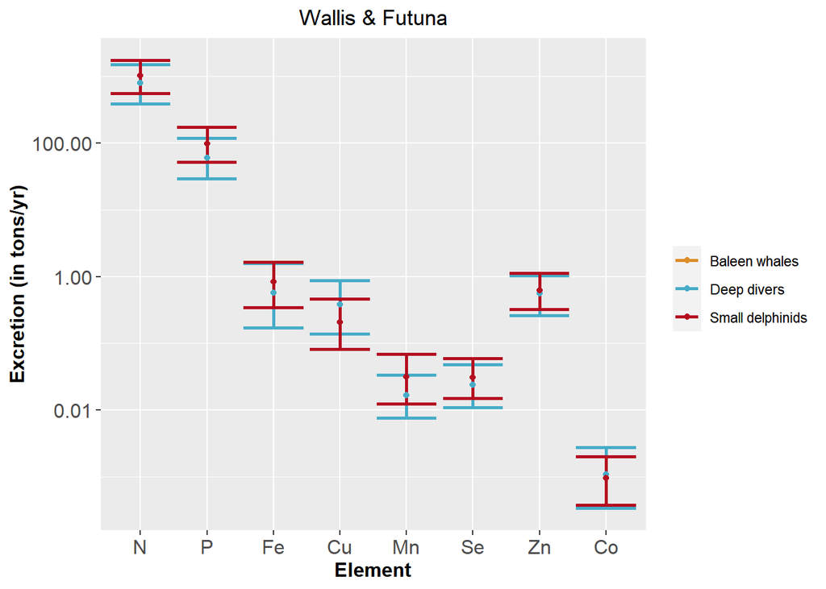

Are the differences significant ?

| Geo_area | Element | Group1 | Group2 | ratio_group1_superior_to_group2 |
| --- | --- | --- | --- | --- |
| Wallis & Futuna | N | Deep divers | Small delphinids | 0.275 |
| Wallis & Futuna | P | Deep divers | Small delphinids | 0.136 |
| Wallis & Futuna | Fe | Deep divers | Small delphinids | 0.197 |
| Wallis & Futuna | Cu | Deep divers | Small delphinids | 0.906 |
| Wallis & Futuna | Mn | Deep divers | Small delphinids | 0.151 |
| Wallis & Futuna | Se | Deep divers | Small delphinids | 0.292 |
| Wallis & Futuna | Zn | Deep divers | Small delphinids | 0.413 |
| Wallis & Futuna | Co | Deep divers | Small delphinids | 0.548 |

What are their relative contribution to total excretion in this area ?

| Geo_area | Eco_gp | Element | mean | mean_total | ratio_contribution |
| --- | --- | --- | --- | --- | --- |
| Wallis & Futuna | Deep divers | N | 790.6326699 | 1815.9930055 | 0.4353721 |
| Wallis & Futuna | Deep divers | P | 60.0694654 | 157.3130678 | 0.3818466 |
| Wallis & Futuna | Deep divers | Fe | 0.5692703 | 1.3996909 | 0.4067114 |
| Wallis & Futuna | Deep divers | Cu | 0.3854517 | 0.5908251 | 0.6523955 |
| Wallis & Futuna | Deep divers | Mn | 0.0166920 | 0.0481435 | 0.3467133 |
| Wallis & Futuna | Deep divers | Se | 0.0238124 | 0.0546747 | 0.4355286 |
| Wallis & Futuna | Deep divers | Zn | 0.5555723 | 1.1734245 | 0.4734623 |
| Wallis & Futuna | Deep divers | Co | 0.0010923 | 0.0020412 | 0.5351070 |
| Wallis & Futuna | Deep divers | As | 0.1872210 | 0.3900887 | 0.4799447 |
| Wallis & Futuna | Small delphinids | N | 1025.3603356 | 1815.9930055 | 0.5646279 |
| Wallis & Futuna | Small delphinids | P | 97.2436024 | 157.3130678 | 0.6181534 |
| Wallis & Futuna | Small delphinids | Fe | 0.8304207 | 1.3996909 | 0.5932886 |
| Wallis & Futuna | Small delphinids | Cu | 0.2053735 | 0.5908251 | 0.3476045 |
| Wallis & Futuna | Small delphinids | Mn | 0.0314515 | 0.0481435 | 0.6532867 |
| Wallis & Futuna | Small delphinids | Se | 0.0308623 | 0.0546747 | 0.5644714 |
| Wallis & Futuna | Small delphinids | Zn | 0.6178522 | 1.1734245 | 0.5265377 |
| Wallis & Futuna | Small delphinids | Co | 0.0009490 | 0.0020412 | 0.4648930 |
| Wallis & Futuna | Small delphinids | As | 0.2028677 | 0.3900887 | 0.5200553 |

# French Polynesia

Survey area only included oceanic habitat here, so we just look at the contributions of taxa.

## Excretion per taxa

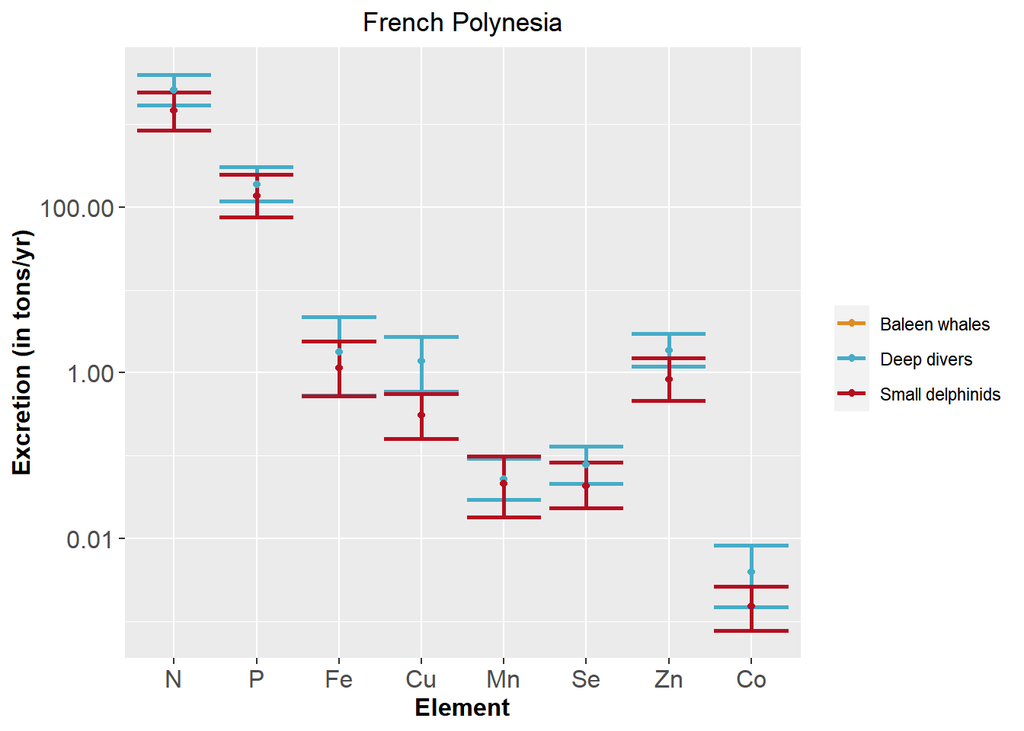

Are the differences significant ?

| Geo_area | Element | Group1 | Group2 | ratio_group1_superior_to_group2 |
| --- | --- | --- | --- | --- |
| French Polynesia | N | Deep divers | Small delphinids | 0.956 |
| French Polynesia | P | Deep divers | Small delphinids | 0.814 |
| French Polynesia | Fe | Deep divers | Small delphinids | 0.691 |
| French Polynesia | Cu | Deep divers | Small delphinids | 1.000 |
| French Polynesia | Mn | Deep divers | Small delphinids | 0.653 |
| French Polynesia | Se | Deep divers | Small delphinids | 0.923 |
| French Polynesia | Zn | Deep divers | Small delphinids | 0.986 |
| French Polynesia | Co | Deep divers | Small delphinids | 0.967 |

What are their relative contribution to total excretion in this area ?

| Geo_area | Eco_gp | Element | mean | mean_total | ratio_contribution |
| --- | --- | --- | --- | --- | --- |
| French Polynesia | Deep divers | N | 2593.4108506 | 4042.8028392 | 0.6414883 |
| French Polynesia | Deep divers | P | 187.7844934 | 325.0387541 | 0.5777296 |
| French Polynesia | Deep divers | Fe | 1.7744432 | 2.9236707 | 0.6069231 |
| French Polynesia | Deep divers | Cu | 1.3796312 | 1.6893448 | 0.8166665 |
| French Polynesia | Deep divers | Mn | 0.0519759 | 0.0981624 | 0.5294887 |
| French Polynesia | Deep divers | Se | 0.0784636 | 0.1220690 | 0.6427809 |
| French Polynesia | Deep divers | Zn | 1.8714270 | 2.7041215 | 0.6920647 |
| French Polynesia | Deep divers | Co | 0.0039358 | 0.0054544 | 0.7215850 |
| French Polynesia | Deep divers | As | 0.6570808 | 0.9890094 | 0.6643827 |
| French Polynesia | Small delphinids | N | 1449.3919886 | 4042.8028392 | 0.3585117 |
| French Polynesia | Small delphinids | P | 137.2542607 | 325.0387541 | 0.4222704 |
| French Polynesia | Small delphinids | Fe | 1.1492276 | 2.9236707 | 0.3930769 |
| French Polynesia | Small delphinids | Cu | 0.3097136 | 1.6893448 | 0.1833335 |
| French Polynesia | Small delphinids | Mn | 0.0461865 | 0.0981624 | 0.4705113 |
| French Polynesia | Small delphinids | Se | 0.0436054 | 0.1220690 | 0.3572191 |
| French Polynesia | Small delphinids | Zn | 0.8326945 | 2.7041215 | 0.3079353 |
| French Polynesia | Small delphinids | Co | 0.0015186 | 0.0054544 | 0.2784150 |
| French Polynesia | Small delphinids | As | 0.3319287 | 0.9890094 | 0.3356173 |